# HLa001_Study_view_from_window

Author

Hanneke

Published

February 22, 2025

## Template Used

LACDR-ISA - Assay (General) v1.0.0

## Title

HLa001_Study_view_from_window

## Date (dd-MM-yyyy)

22-02-2025

## Description or Purpose

To calculate statistics on what I see outside of my window

### Background

I needed an example for this tutorial and was staring out of my window, so that is what I chose.

### Data sources

A table of objects that I counted. Data stored in data/raw_data/20230502_HLa001_things_I_see_from_my_window.csv

### Analysis plan

1. Explore the data
2. Plot the data
3. Save the results

## Results

### 0. Preparations

#### Load R libraries

```r
library(tidyverse)
library(here)
```

#### Set input and output directories

Print where the script was run from:

```r
here::here()
```

```
[1] "C:/Users/hanne/surfdrive/Investigations/rspacer_related/workshop"
```

Set input data directory.

```r
data_dir <- here("Tutorial_2_using_LACDR-ISA/data/raw_data")
str_glue("Using data from {data_dir}")
```

```
Using data from C:/Users/hanne/surfdrive/Investigations/rspacer_related/workshop/Tutorial_2_using_LACDR-ISA/data/raw_data
```

```r
stopifnot(dir.exists(data_dir))
```

Set output data directory and create if it does not exist.

```r
datestamp <- str_remove_all(Sys.Date(), "-")
output_dir <- here("Tutorial_2_using_LACDR-ISA/results", str_glue("HLa001_{datestamp}_output"))
if(!dir.exists(output_dir)) dir.create(output_dir)
str_glue("Output directory path is {output_dir}")
```

```
Output directory path is C:/Users/hanne/surfdrive/Investigations/rspacer_related/workshop/Tutorial_2_using_LACDR-ISA/results/HLa001_20250222_output
```

#### Define functions

```r
source(here("Tutorial_2_using_LACDR-ISA/code/functions/example_function.R"))
```

### 1. Load data

```r
object_info <- read_csv(here(data_dir, "20230502_HLa001_things_I_see_from_my_window.csv"))
str(object_info)
```

```
spc_tbl_ [6 × 3] (S3: spec_tbl_df/tbl_df/tbl/data.frame)
 $ object: chr [1:6] "tree" "grass" "building" "car" ...
 $ color : chr [1:6] "green" "green" "blue" "white" ...
 $ amount: num [1:6] 8 1 3 8 1 1
 - attr(*, "spec")=
  .. cols(
  ..   object = col_character(),
  ..   color = col_character(),
  ..   amount = col_double()
  .. )
 - attr(*, "problems")=<externalptr>
```

```r
dim(object_info)
```

```
[1] 6 3
```

```r
head(object_info)
```

| object | color | amount |
| --- | --- | --- |
| tree | green | 8 |
| grass | green | 1 |
| building | blue | 3 |
| car | white | 8 |
| car | red | 1 |
| car | orange | 1 |

Data looks ok.

### 2. Get information on all cars

```r
filter(object_info, object == "car")
```

| object | color | amount |
| --- | --- | --- |
| car | white | 8 |
| car | red | 1 |
| car | orange | 1 |

So I see three car colors, and I think 10 in total, but let’s count.

```r
object_info %>%
  group_by(object) %>%
  summarise(sum = sum(amount))
```

| object | sum |
| --- | --- |
| building | 3 |
| car | 10 |
| grass | 1 |
| tree | 8 |

### 3. Plot the amount of objects

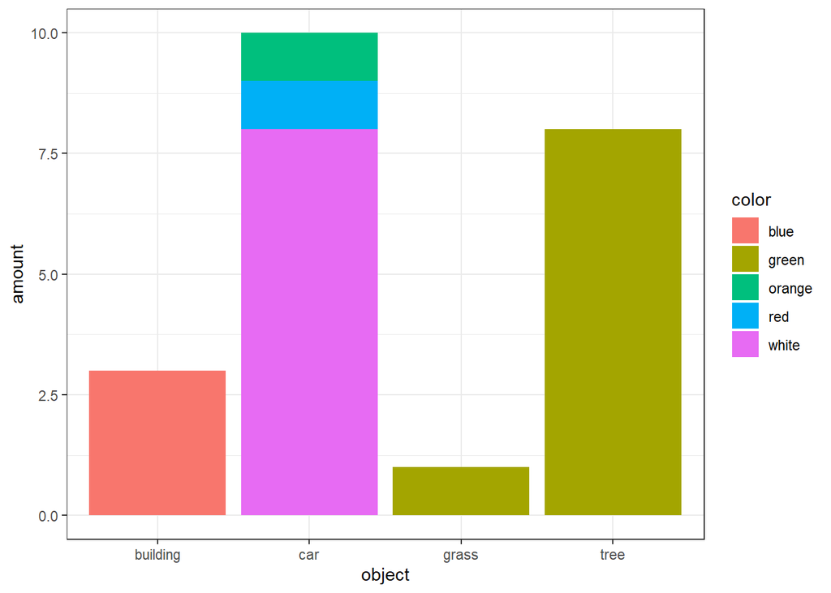

```r
p1 <- object_info %>%
  ggplot(aes(x = object, y = amount, fill = color)) +
  geom_col() +
  theme_bw()
p1
```

I clearly see a lot of cars and trees.

#### Save plot

```r
ggsave(here(output_dir, "bar_plot_with_info_on_views.png"), p1)
```

### 4. Count to three

To see if I can source and use functions:

```r
count_to_three()
```

```
[1] "one, two, three!"
```

## Conclusion

Plots were generated and saved. I saw a lot of trees and cars.

### Doubts and limitations

I did not get the colors in the plot the way I want. Redo tomorrow?

### Future assays

Maybe study if I also saw birds.